# project_four

## Introduction

In this project, my goal to uncover how the variety of coffee changes the tasting qualities. Coffee varieties are specific types—like Granny Smith apples or Golden Retriever dogs. Beyond flavor, the variety also influences factors import to growers, such as disease resistance, yield, difficulty of growing, etc. It's clear to many that different regions of the world have unique flavors, such as fruity flavors from Ethiopia or chocolately flavors from Brazil. Less people, including myself, however, understand the varietal's role in the final cup. I'll explore the data to gain a more complete understanding of this unique aspect of coffee.

I will be analyzing coffee metrics using K-means clustering to uncover patterns in the data. I found this data on DataCrayon.com (https://datacrayon.com/data-is-beautiful/arabica-coffee-beans-origin-and-variety/) in an article exploring the connections between variety and country of origin. The author of the article forked the dataset from Github, which was originally web scraped from the Coffee Quality Institute website. The data contains features with a variety of different aspects of coffee beans, including owner, country of origin, varietal, and taste metrics, among others.

K-means clustering is a common type of unsupervised learning algorithm. It finds clusters in data using centroid-based clustering. The algorithm includes the following steps:

1. Choose initial randomly chosen centroids.
2. Assign each point to the nearest centroid.
3. Recalculate the centroids as means of the points in each cluster.
4. Repeat this process until the centroids do not change after recalculation.

Because centroids are randomly chosen, your k value is essential to the efficacy of the model. To find an optimal k value that neither generalizes nor overfits the data, the elbow method is used, in which k is plotted against within-cluster sum of squares. Where the graph begins to level off, or forms an 'elbow', is likely your optimal k value.

My key questions I would like to answer in this project are:

- What are the key differences between the different varieties of coffee?
- What are the metrics most important to determining variety specific qualities?
- How might these difference impact the consumer and producer?

## Data understanding

```python
# Imports
import pandas as pd
import numpy as np
import matplotlib.pyplot as plt
from sklearn.cluster import KMeans
import seaborn as sns
df = pd.read_csv("https://datacrayon.com/datasets/arabica_data.csv")
```

```python
df.shape
```

```
(1311, 44)
```

```python
df.dtypes
```

```
Unnamed: 0                 int64
Species                   object
Owner                     object
Country.of.Origin         object
Farm.Name                 object
Lot.Number                object
Mill                      object
ICO.Number                object
Company                   object
Altitude                  object
Region                    object
Producer                  object
Number.of.Bags             int64
Bag.Weight                object
In.Country.Partner        object
Harvest.Year              object
Grading.Date              object
Owner.1                   object
Variety                   object
Processing.Method         object
Aroma                    float64
Flavor                   float64
Aftertaste               float64
Acidity                  float64
Body                     float64
Balance                  float64
Uniformity               float64
Clean.Cup                float64
Sweetness                float64
Cupper.Points            float64
Total.Cup.Points         float64
Moisture                 float64
Category.One.Defects       int64
Quakers                  float64
Color                     object
Category.Two.Defects       int64
Expiration                object
Certification.Body        object
Certification.Address     object
Certification.Contact     object
unit_of_measurement       object
altitude_low_meters      float64
altitude_high_meters     float64
altitude_mean_meters     float64
dtype: object
```

```python
df['Variety'].unique()
```

```
array([nan, 'Other', 'Bourbon', 'Catimor', 'Ethiopian Yirgacheffe',
       'Caturra', 'SL14', 'Sumatra', 'SL34', 'Hawaiian Kona',
       'Yellow Bourbon', 'SL28', 'Gesha', 'Catuai', 'Pacamara', 'Typica',
       'Sumatra Lintong', 'Mundo Novo', 'Java', 'Peaberry', 'Pacas',
       'Mandheling', 'Ruiru 11', 'Arusha', 'Ethiopian Heirlooms',
       'Moka Peaberry', 'Sulawesi', 'Blue Mountain', 'Marigojipe',
       'Pache Comun'], dtype=object)
```

```python
df.isna().sum()
```

```
Unnamed: 0                  0
Species                     0
Owner                       7
Country.of.Origin           1
Farm.Name                 356
Lot.Number               1041
Mill                      310
ICO.Number                148
Company                   209
Altitude                  223
Region                     57
Producer                  230
Number.of.Bags              0
Bag.Weight                  0
In.Country.Partner          0
Harvest.Year               47
Grading.Date                0
Owner.1                     7
Variety                   201
Processing.Method         152
Aroma                       0
Flavor                      0
Aftertaste                  0
Acidity                     0
Body                        0
Balance                     0
Uniformity                  0
Clean.Cup                   0
Sweetness                   0
Cupper.Points               0
Total.Cup.Points            0
Moisture                    0
Category.One.Defects        0
Quakers                     1
Color                     267
Category.Two.Defects        0
Expiration                  0
Certification.Body          0
Certification.Address       0
Certification.Contact       0
unit_of_measurement         0
altitude_low_meters       227
altitude_high_meters      227
altitude_mean_meters      227
dtype: int64
```

Tasting notes have no null values, but variety has 201 null values. It's unlikely that the null values are due to the coffee being blends, as blends would likely be included as a category. It's more likely that it's due to incomplete record keeping. As null/unknown variety might be indicative of some pattern in the data, I'll group it with the 'other' category, and include it in the analysis.

```python
df['Variety'] = df['Variety'].replace({'Other': 'Unknown'}).fillna('Unknown')
df['Aroma']
```

```
0       8.67
1       8.75
2       8.42
3       8.17
4       8.25
        ...
1306    7.08
1307    6.75
1308    7.25
1309    7.50
1310    0.00
Name: Aroma, Length: 1311, dtype: float64
```

## Visualization

The different qualities of each coffee, like aroma and sweetness, are measured on a scale from 1-10. According to the Specialty Coffee Association, these scores are based on quality of the metric, rather than preference or strength. Let's first plot the different metrics to see if we can find any preliminary patterns.

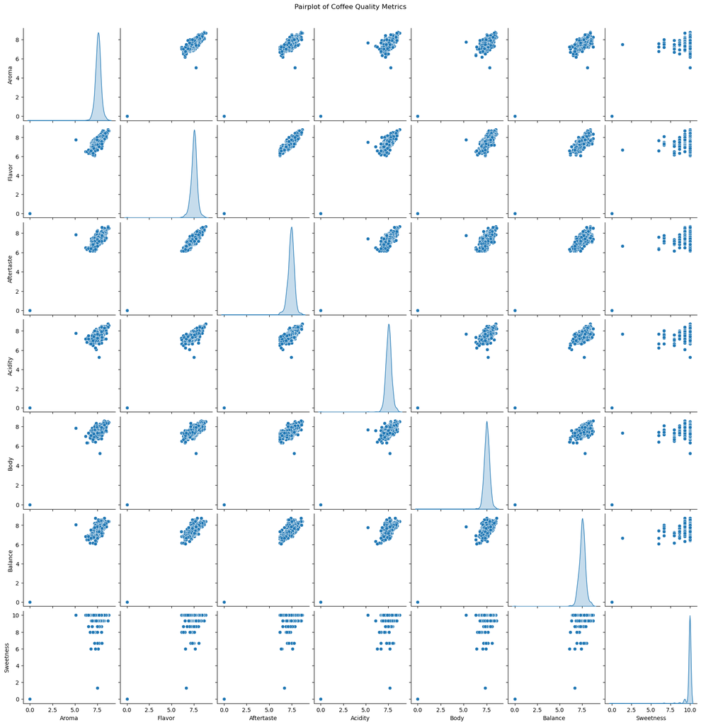

```python
quality_cols = ['Aroma', 'Flavor', 'Aftertaste', 'Acidity', 'Body', 'Balance', 'Sweetness']
sns.pairplot(df[quality_cols], diag_kind='kde')
plt.suptitle("Pairplot of Coffee Quality Metrics", y=1.02)
plt.show()
```

```python
import plotly.express as px

fig = px.scatter_matrix(
                    df,
                    dimensions=quality_cols,
                    color='Variety',
                    title="Scatter Matrix of Coffee Quality Metrics"
                    )

fig.show()
```

[output not shown]

```python
condition_1 = (df['Variety'] == 'Caturra') & (df['Aroma'] == 0)
condition_2 = (df['Variety'] == 'Caturra') & (df['Aroma'] == 5.08)
condition_3 = (df['Variety'] == 'Caturra') & (df['Acidity'] == 5.25)
condition_4 = (df['Variety'] == 'Unknown') & (df['Body'] == 5.25)
condition_5 = (df['Variety'] == 'Catuai') & (df['Sweetness'] == 1.33)

combined_conditions = condition_1 | condition_2 | condition_3 | condition_4 | condition_5
df= df[~combined_conditions]
```

```python
# Replotted after removed outliers

import plotly.express as px

fig = px.scatter_matrix(
                    df,
                    dimensions=quality_cols,
                    color='Variety',
                    title="Scatter Matrix of Coffee Quality Metrics"
                    )

fig.show()
```

[output not shown]

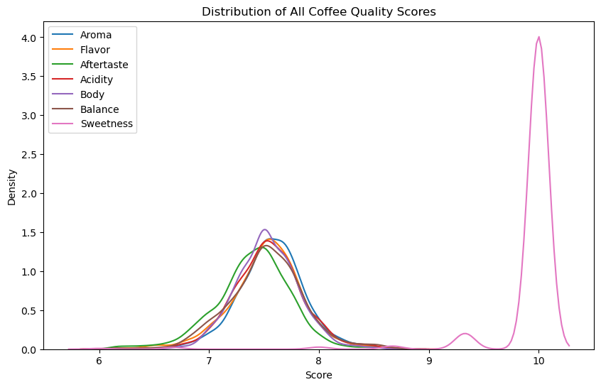

```python
plt.figure(figsize=(10,6))
for col in quality_cols:
    sns.kdeplot(df[col], label=col)
plt.legend()
plt.title('Distribution of All Coffee Quality Scores')
plt.xlabel('Score')
plt.ylabel('Density')
plt.show()
```

```python
print(f"Total 10s: {(df['Sweetness'] == 10).sum()}")
```

```
Total 10s: 1215
```

```python
quality_cols.remove('Sweetness')
```

## Modeling

[output not shown]

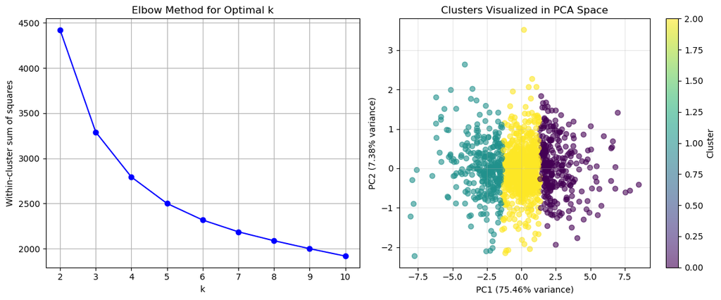

```
Cluster characteristics:

Mean values per cluster:
         Aroma  Flavor  Aftertaste  Acidity  Body  Balance
cluster
0         7.89    7.90        7.79     7.90  7.83     7.90
1         7.23    7.10        6.97     7.20  7.22     7.11
2         7.58    7.55        7.42     7.53  7.52     7.54

Cluster sizes:
cluster
0    302
1    302
2    702
Name: count, dtype: int64
Variety-cluster distribution:

Percentage of each variety in each cluster:
cluster                    0      1      2
Variety
Arusha                   0.0   20.0   80.0
Blue Mountain            0.0    0.0  100.0
Bourbon                 18.6   23.0   58.4
Catimor                 25.0    5.0   70.0
Catuai                  15.1   31.5   53.4
Caturra                 24.9   15.4   59.7
Ethiopian Heirlooms      0.0    0.0  100.0
Ethiopian Yirgacheffe  100.0    0.0    0.0
Gesha                   16.7    8.3   75.0
Hawaiian Kona           34.1   22.7   43.2
Java                    50.0   50.0    0.0
Mandheling              66.7    0.0   33.3
Marigojipe               0.0    0.0  100.0
Moka Peaberry            0.0    0.0  100.0
Mundo Novo              12.1   18.2   69.7
Pacamara                37.5   25.0   37.5
Pacas                    7.7   38.5   53.8
Pache Comun              0.0  100.0    0.0
Peaberry                20.0   20.0   60.0
Ruiru 11                 0.0    0.0  100.0
```

[output cut: 28 more lines]

```
Mundo Novo              7.48    7.49        7.34     7.46  7.48     7.44
Pacamara                7.66    7.69        7.46     7.57  7.50     7.60
Pacas                   7.40    7.41        7.23     7.50  7.38     7.39
Pache Comun             7.42    7.17        7.33     7.42  7.25     7.33
Peaberry                7.62    7.37        7.33     7.52  7.50     7.33
Ruiru 11                7.71    7.46        7.50     7.54  7.67     7.50
SL14                    7.88    7.72        7.59     7.68  7.66     7.64
SL28                    7.74    7.73        7.69     7.82  7.70     7.81
SL34                    7.77    7.79        7.67     7.88  7.77     7.73
Sulawesi                7.50    7.58        7.42     7.58  7.58     7.50
Sumatra                 7.47    7.70        7.64     7.86  7.72     7.72
Sumatra Lintong         7.75    7.83        7.67     8.00  8.08     7.83
Typica                  7.47    7.38        7.28     7.40  7.40     7.35
Unknown                 7.62    7.60        7.48     7.60  7.59     7.60
Yellow Bourbon          7.50    7.54        7.40     7.47  7.57     7.57
```

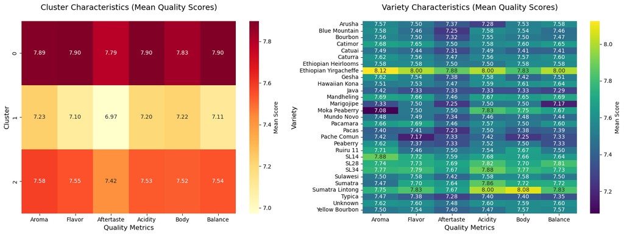

```
Feature importance by cluster:

Cluster centers (original scale):
   Aroma  Flavor  Aftertaste  Acidity  Body  Balance
0   7.89    7.90        7.79     7.90  7.83     7.90
1   7.23    7.10        6.97     7.20  7.22     7.11
2   7.58    7.55        7.42     7.53  7.52     7.54

Cluster 0 distinguishing features:
Acidity       7.90
Flavor        7.90
Balance       7.90
Aroma         7.89
Body          7.83
Aftertaste    7.79
Name: 0, dtype: float64

Cluster 1 distinguishing features:
Aroma         7.23
Body          7.22
Acidity       7.20
Balance       7.11
Flavor        7.10
Aftertaste    6.97
Name: 1, dtype: float64

Cluster 2 distinguishing features:
Aroma         7.58
Flavor        7.55
Balance       7.54
Acidity       7.53
Body          7.52
Aftertaste    7.42
Name: 2, dtype: float64
```

```python
from sklearn.preprocessing import StandardScaler
from sklearn.cluster import KMeans
from sklearn.decomposition import PCA

X = df[quality_cols]

# Scaling
scaler = StandardScaler()
X_scaled = scaler.fit_transform(X)

#  Determining optimal k using Elbow Method
inertias = []
silhouette_scores = []
K_range = range(2, 11)

for k in K_range:
    kmeans = KMeans(n_clusters=k, random_state=42, n_init=10)
    kmeans.fit(X_scaled)
    inertias.append(kmeans.inertia_)

plt.figure(figsize=(12, 5))

# Plotting different k values
plt.subplot(1, 2, 1)
plt.plot(K_range, inertias, 'bo-')
plt.xlabel('k')
plt.ylabel('Within-cluster sum of squares')
plt.title('Elbow Method for Optimal k')
plt.grid(True)

k = 3
kmeans = KMeans(n_clusters=k, random_state=42, n_init=10)
df['cluster'] = kmeans.fit_predict(X_scaled)

pca = PCA(n_components=2)
X_pca = pca.fit_transform(X_scaled)

plt.subplot(1, 2, 2)
scatter = plt.scatter(X_pca[:, 0], X_pca[:, 1], c=df['cluster'], cmap='viridis', alpha=0.6)
plt.xlabel(f'PC1 ({pca.explained_variance_ratio_[0]:.2%} variance)')
plt.ylabel(f'PC2 ({pca.explained_variance_ratio_[1]:.2%} variance)')
plt.title('Clusters Visualized in PCA Space')
plt.colorbar(scatter, label='Cluster')
plt.grid(True, alpha=0.3)

plt.tight_layout()
plt.savefig('clustering_analysis.png', dpi=300, bbox_inches='tight')
plt.show()

# Cluster characteristics
print("Cluster characteristics: ")
cluster_summary = df.groupby('cluster')[quality_cols].mean()
print("\nMean values per cluster:")
print(cluster_summary.round(2))
print("\nCluster sizes:")
print(df['cluster'].value_counts().sort_index())

# Variety-cluster correlations
print("Variety-cluster distribution:")
variety_cluster = pd.crosstab(df['Variety'], df['cluster'], normalize='index') * 100
print("\nPercentage of each variety in each cluster:")
print(variety_cluster.round(1))

# Correlation between varieties and metrics
print("Vareity-metric correlations:")
variety_metrics = df.groupby('Variety')[quality_cols].mean()
print("\nMean quality metrics by variety:")
print(variety_metrics.round(2))

#Heatmap of cluster characteristics
fig, axes = plt.subplots(1, 2, figsize=(16, 6))

sns.heatmap(cluster_summary, annot=True, fmt='.2f', cmap='YlOrRd',
            ax=axes[0], cbar_kws={'label': 'Mean Score'})
axes[0].set_title('Cluster Characteristics (Mean Quality Scores)', fontsize=14, pad=20)
axes[0].set_xlabel('Quality Metrics', fontsize=12)
axes[0].set_ylabel('Cluster', fontsize=12)

# Variety characteristics heatmap
sns.heatmap(variety_metrics, annot=True, fmt='.2f', cmap='viridis',
            ax=axes[1], cbar_kws={'label': 'Mean Score'})
axes[1].set_title('Variety Characteristics (Mean Quality Scores)', fontsize=14, pad=20)
axes[1].set_xlabel('Quality Metrics', fontsize=12)
axes[1].set_ylabel('Variety', fontsize=12)

plt.tight_layout()
plt.savefig('heatmaps.png', dpi=300, bbox_inches='tight')
plt.show()

# Feature importance analysis

print("Feature importance by cluster:")
cluster_centers = scaler.inverse_transform(kmeans.cluster_centers_)
centers_df = pd.DataFrame(cluster_centers, columns=quality_cols)
print("\nCluster centers (original scale):")
print(centers_df.round(2))

# Distinguishing features for each cluster
for i in range(k):
    print(f"\nCluster {i} distinguishing features:")
    cluster_center = centers_df.iloc[i]
    ranked_features = cluster_center.sort_values(ascending=False)
    print(ranked_features.round(2))
```

## Clustering Analysis

While clustering worked, the data has low dispersion, and almost all observations have similar values for taste metrics, and most varieties participate in several clusters. This highlights that while variety is important, the quality of coffee is highly dependent on several factors.

## Impact

My intention with this project is to educate myself as well as the reader of the different coffee varietals and their flavor. Through the viewing of this project, a reader may be able to find new coffees that they may enjoy and fit their preferences.

A few major limitations in this project are present. Firstly, the standard tasting protocol for these coffees includes roasting each coffee to a very light level. This highlights the coffee specific qualities, but inherently favors coffees that perform well at a light roast, such as Ethiopian coffee. For many people, they prefer dark, rich espresso meant to be mixed into a drink with milk and other flavorings. In this case, some coffees that perform poorly on the cupping tests may actually taste much better in practice than other higher rated coffees.

Another limitation is the lack of description on the unique flavors and characteristics of each variety. Per SCA rules, the metrics are based on objective quality, rather than unique characters, so this dataset was unable to support an analysis of characteristics, and rather grouped coffee based on quality. This is still useful, as variety is only one part of the complex process of coffee production, and a viewer may still be able to find coffees that match their preferences through this analysis.

Many areas of the world depend on coffee as a major contributor to economic livelihood. Through viewing this analysis, a reader may decide to stop buying a coffee that was, for example, grouped into cluster 1, even though the coffee is perfectly fine. If enough people switched away from this particular coffee, this could severely impact the livelihood of those who work at coffee farms. To avoid this, it is important that I and others emphasis the fact that data science is both science and art, is subject to poor input data, and is liable to inaccurate analysis. In addition, all coffees in this dataset may be preferred by different individuals, even if it scored lower on cupper scores.

## References

“PlotAPI - Beautiful Visualizations, Made Easy.” Plotapi.com, 2024, plotapi.com/.

Rostami, Dr Shahin. “Arabica Coffee Beans - Origin and Variety | Data Crayon.” Datacrayon.com, 29 Oct. 2020, datacrayon.com/data-is-beautiful/arabica-coffee-beans-origin-and-variety/.

“Specialty Coffee Association.” Specialty Coffee Association, 2024, sca.coffee/.

“K Means Clustering – Introduction.” GeeksforGeeks, 2 May 2017, www.geeksforgeeks.org/machine-learning/k-means-clustering-introduction/.